# M5W2

Thomas Goeppert

24 2 2020

# Coursera - Reproducible Research - Course Project 1

## Load Librarys and set Working Directory

```r
library(ggplot2)
library(tidyverse)
setwd("C:/temp/Coursera/M5W2")
```

## 1. Loading and preprocessing the data

### 1.1. Load Data

```r
activity <- read.csv("activity.csv")
```

### 1.2 Process/transform the data (if necessary) into a format suitable for your analysis

```r
str(activity)
```

```
## 'data.frame':    17568 obs. of  3 variables:
##  $ steps   : int  NA NA NA NA NA NA NA NA NA NA ...
##  $ date    : Factor w/ 61 levels "2012-10-01","2012-10-02",..: 1 1 1 1 1 1 1 1 1 1 ...
##  $ interval: int  0 5 10 15 20 25 30 35 40 45 ...
```

## 2. What is mean total number of steps taken per day?

### 2.1 Calculate the total number of steps taken per day

```r
activity_day <- activity %>%
            filter(!is.na(steps)) %>%
            group_by(date) %>%
            summarise(steps = sum(steps))
```

### 2.2 If you do not understand the difference between a histogram and a barplot, research the difference between them. Make a histogram of the total number of steps taken each day

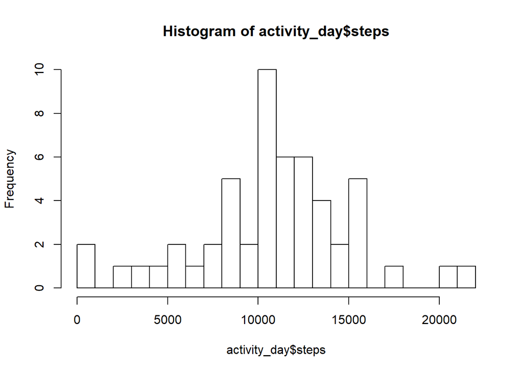

```r
hist(activity_day$steps, breaks = 16)
```

### 2.3 Calculate and report the mean and median of the total number of steps taken per day

```r
mean(activity_day$steps)
```

```
## [1] 10766.19
```

```r
median(activity_day$steps)
```

```
## [1] 10765
```

## 3. What is the average daily activity pattern?

### 3.1 Make a time series plot of the 5-minute interval (x-axis) and the average number of steps taken, averaged across all days (y-axis)

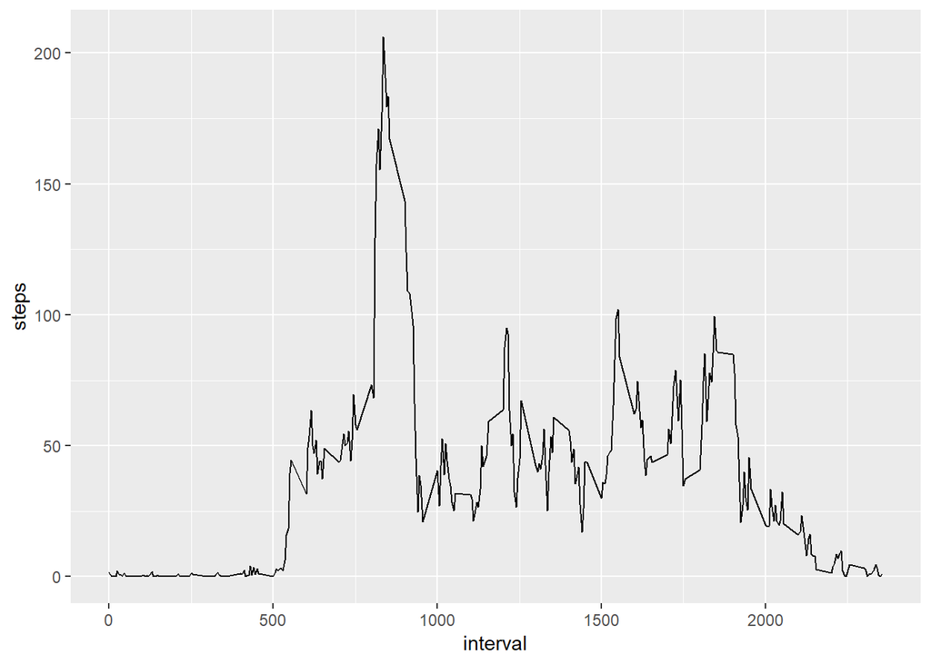

```r
activity_mean <- activity %>%
            filter(!is.na(steps)) %>%
            group_by(interval) %>%
            summarise(steps = mean(steps))
ggplot(activity_mean, aes(interval,steps))+
            geom_line()
```

```r
activity %>%
            filter(!is.na(steps)) %>%
            group_by(interval) %>%
            summarise(steps = mean(steps)) %>%
            filter(steps == (max(activity_day$steps)))
```

```
## # A tibble: 0 x 2
## # ... with 2 variables: interval <int>, steps <dbl>
```

## 4 Imputing missing values

## Note that there are a number of days/intervals where there are missing values. The presence of missing days may ##introduce bias into some calculations or summaries of the data.

### 4.1 Calculate and report the total number of missing values in the dataset (i.e. the total number of rows with NAs.

```r
activity %>%
            filter(is.na(steps)) %>%
            nrow()
```

```
## [1] 2304
```

### 4.3 Create a new dataset that is equal to the original dataset but with the missing data filled in.

```r
activity_nona <- activity

activity_nona$steps[is.na(activity$steps)] <- subset(activity_mean$steps, activity_mean$interval == activity$interval[is.na(activity$steps)])
```

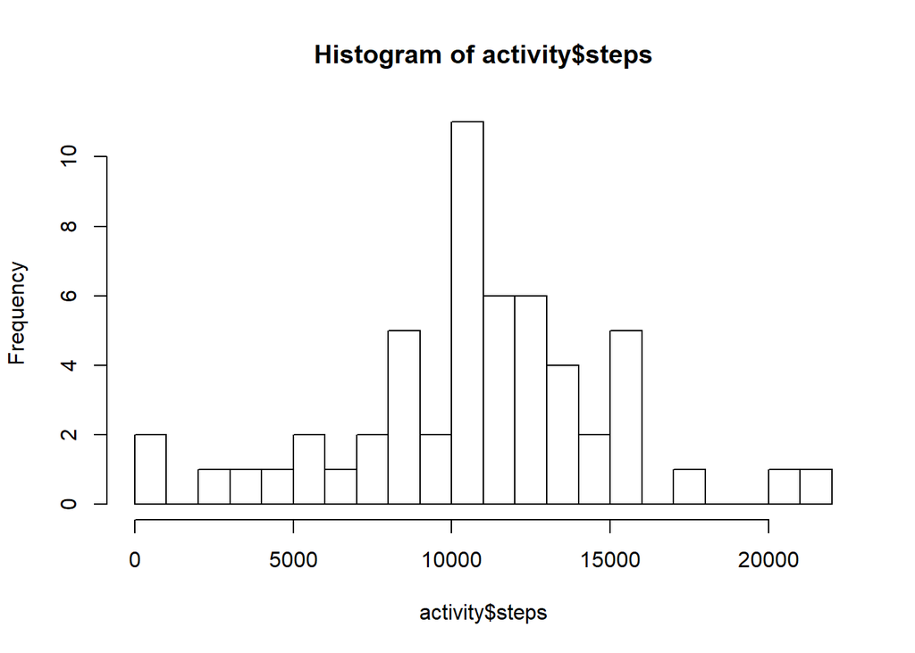

```r
activity <- activity_nona %>%
            filter(!is.na(steps)) %>%
            group_by(date) %>%
            summarise(steps = sum(steps))

hist(activity$steps, breaks = 16)
```

```r
mean(activity_day$steps)
```

```
## [1] 10766.19
```

```r
median(activity_day$steps)
```

```
## [1] 10765
```

## 5 Are there differences in activity patterns between weekdays and weekends? For this part the weekdays() function may be of some help here. Use the dataset with the filled-in missing values for this part.

### 5.1 Create a new factor variable in the dataset with two levels – “weekday” and “weekend” indicating whether a given date is a weekday or weekend day.

```r
activity_wd <- activity_nona %>%
            mutate(wday = weekdays(as.Date(date)))

activity_wd$weekend <-as.factor(activity_wd$wday=="Samstag"|activity_wd$wday=="Sonntag")
levels(activity_wd$weekend) <- c("Weekday", "Weekend")
```

### 5.2 Make a panel plot containing a time series plot (i.e. type = “l”) of the 5-minute interval (x-axis) and the average number of steps taken, averaged across all weekday days or weekend days (y-axis). See the README file in the GitHub repository to see an example of what this plot should look like using simulated data.

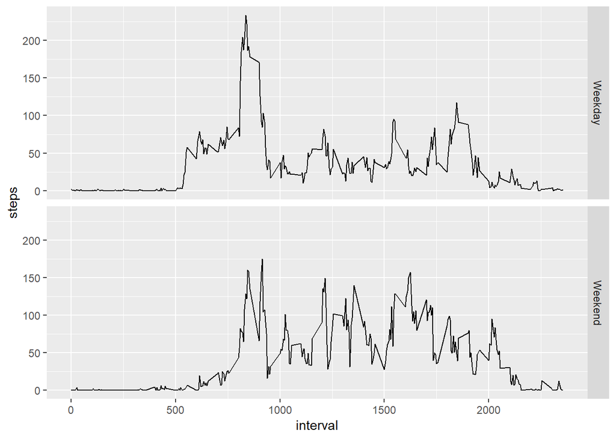

```r
activity_mean <- activity_wd %>%
            filter(!is.na(steps)) %>%
            group_by(weekend, interval) %>%
            summarise(steps = mean(steps))
ggplot(activity_mean, aes(interval,steps))+
            geom_line() +
            facet_grid(weekend~.)
```